# Exercise 8.12

Kári Hlynsson

March 2024

Apply boosting, bagging, random forests, and BART to a data set of your choice. Be sure to fit the models on a training set and to evaluate their performance on a test set. How accurate are the results compared to simple methods like linear or logistic regression? Which of these approaches yields the best performance?

```r
library(ISLR2)
library(Biostatistics)

set.seed(1)

data(longevity)

n <- nrow(longevity)
p <- ncol(longevity)

# convert some stuff to factors
longevity$class <- as.factor(longevity$class)
longevity$volancy <- as.factor(longevity$volancy)
longevity$fossoriallity <- as.factor(longevity$fossoriallity)
longevity$foraging_environment <- as.factor(longevity$foraging_environment)
longevity$daily_activity <- as.factor(longevity$daily_activity)

longevity <- subset(longevity, select = -c(species, order))
```

Pair plot of the data:

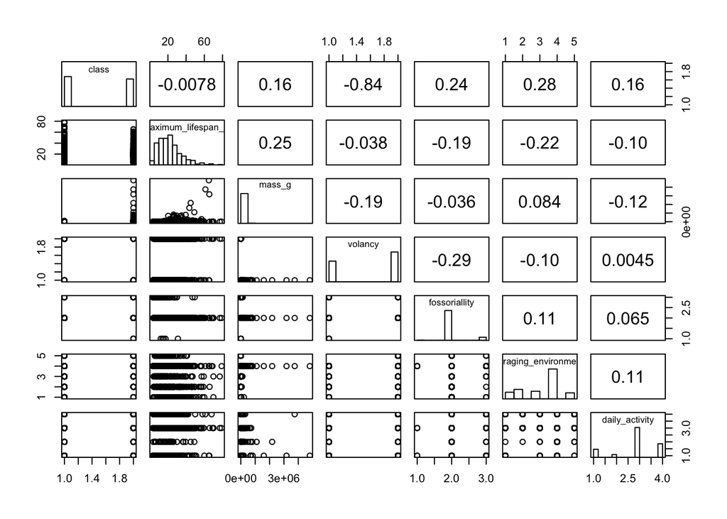

```r
pair_plot(longevity)
```

Let’s log-transform the mass, since it seems to be exponentially distributed:

```r
longevity$log_mass_g <- log(longevity$mass_g, base = 10)
longevity <- subset(longevity, select = -mass_g)
```

Do the pair plot again:

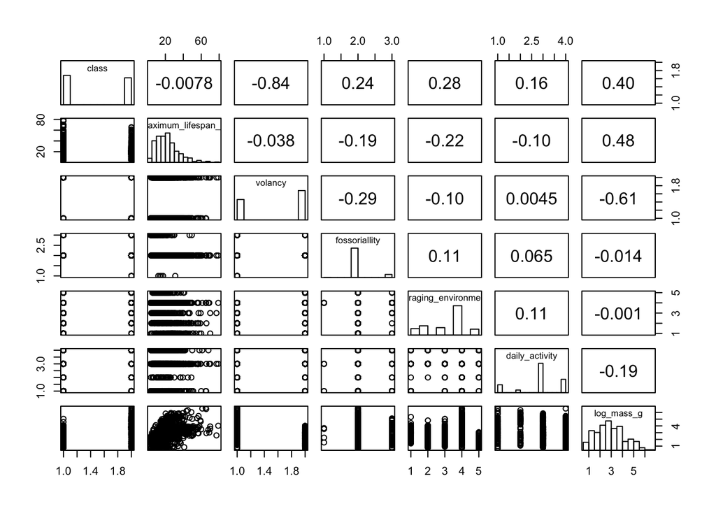

```r
pair_plot(longevity)
```

Split the data into a training and test set:

```r
# split data into training and test set
prop_train <- 0.75
s <- sample(
  c(TRUE, FALSE),
  size = n,
  replace = TRUE,
  prob = c(prop_train, 1 - prop_train)
)

train <- longevity[s, ]
test <- longevity[!s, ]

method_eff <- data.frame(
  method = character(),
  mse_tr = double(),
  mse_ts = double()
)
```

This data set contains data on the maximum lifespan of various species of mammals and birds along with other predictors, such as mass, volancy (ability to fly), foraging environment and so on. We will try to model the maximum lifespan of these animals as a function of the aforementioned predictors in the data set, excluding species and order since they are more granular nomenclature which is unlikely to be give useful results (too many levels).

For fun, let’s start with a regression tree to get a (possible not-so-accurate) feel for the data. We will keep a track of the training and test set MSE for the different methods employed here to see which ones are most effective in describing the relationship in the data.

```r
library(tree)
longevity_tree <- tree(maximum_lifespan_yr ~ ., data = train)

tree_pred_tr <- predict(longevity_tree, train)
tree_pred_ts <- predict(longevity_tree, test)

tree_mse_tr <- mean((tree_pred_tr - train$maximum_lifespan_yr)^2)
tree_mse_ts <- mean((tree_pred_ts - test$maximum_lifespan_yr)^2)

method_eff[1, ] <- c("Regression Tree", tree_mse_tr, tree_mse_ts)
```

## Boosting

Perform boosting and optimise the shrinkage hyperparameter, $\lambda$. To prevent trees from becoming too convoluted I set `interaction.depth` to 5.

```r
library(gbm3)
library(pbapply)

n_trees <- 1000
lambda <- 10^seq(-10, -0.2, by = 0.1)

res_boost <- pblapply(lambda, function(l) {
  longevity_boost_l <- gbm(
    maximum_lifespan_yr ~ .,
    data = train,
    distribution = "gaussian",
    n.trees = n_trees,
    interaction.depth = 5,
    shrinkage = l
  )

  boost_l_pred_tr <- predict(longevity_boost_l, train, n.trees = n_trees)
  boost_l_pred_ts <- predict(longevity_boost_l, test, n.trees = n_trees)

  boost_l_mse_tr <- mean((boost_l_pred_tr - train$maximum_lifespan_yr)^2)
  boost_l_mse_ts <- mean((boost_l_pred_ts - test$maximum_lifespan_yr)^2)

  return(c(l, boost_l_mse_tr, boost_l_mse_ts))
})
```

Analysis

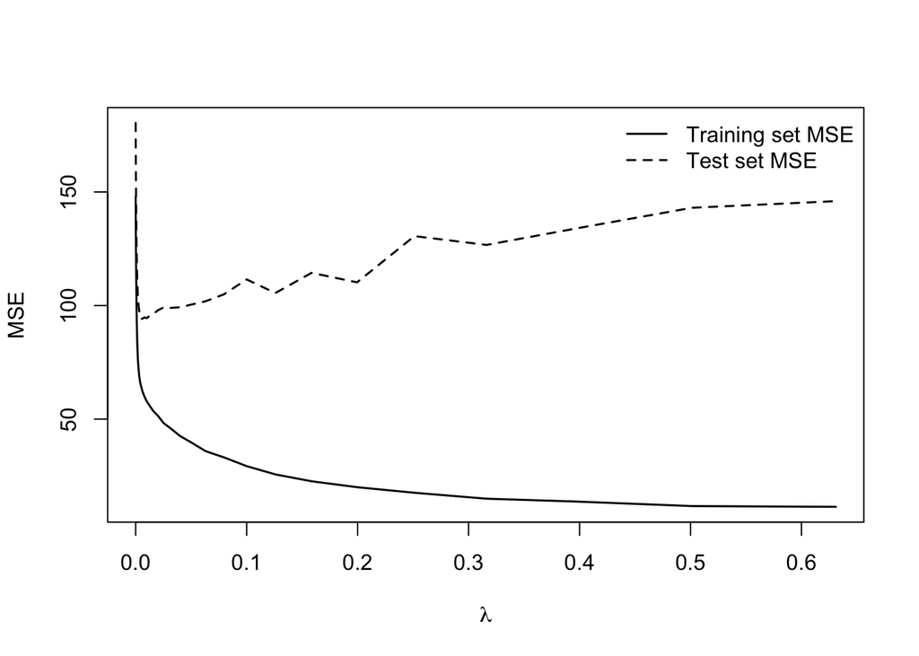

```r
boost_mse <- data.frame(do.call(rbind, res_boost))
colnames(boost_mse) <- c("lambda", "train_mse", "test_mse")

plot(
  boost_mse$lambda,
  boost_mse$train_mse,
  type = "l",
  lwd = 1.5,
  ylim = range(boost_mse$train_mse, boost_mse$test_mse),
  xlab = expression(lambda),
  ylab = "MSE"
)

lines(boost_mse$lambda, boost_mse$test_mse, lwd = 1.5, lty = 2)

legend(
  "topright",
  bty = "n",
  legend = c("Training set MSE", "Test set MSE"),
  lty = 1:2,
  lwd = 1.5
)
```

The training set error tends to zero as $\lambda$ increases, but the test error has a minima close to zero, due to overfitting.

```r
ind <- which.min(boost_mse$test_mse)
boost_lambda_opt <- boost_mse$lambda[ind]
boost_opt_mse_tr <- boost_mse$train_mse[ind]
boost_opt_mse_ts <- boost_mse$test_mse[ind]

method_eff[2, ] <- c("Boosting", boost_opt_mse_tr, boost_opt_mse_ts)
```

The optimal value for the shrinkage parameter is $\lambda = 0.0050119$. This achieves a training set MSE of 64.2222571 and a test set MSE of 94.1134596.

## Bagging

It’s in the bag!

```r
library(randomForest)

longevity_bag <- randomForest(
  maximum_lifespan_yr ~ .,
  data = train,
  mtry = 6,
  importance = TRUE
)

longevity_bag
```

```
##
## Call:
##  randomForest(formula = maximum_lifespan_yr ~ ., data = train,      mtry = 6, importance = TRUE)
##                Type of random forest: regression
##                      Number of trees: 500
## No. of variables tried at each split: 6
##
##           Mean of squared residuals: 83.27691
##                     % Var explained: 43.77
```

Compute the MSE of the training and test set (we already have the traning MSE in the output, but I want the exact quantity).

```r
bag_pred_ts <- predict(longevity_bag, test)

bag_mse_tr <- mean((longevity_bag$predicted - train$maximum_lifespan_yr)^2)
bag_mse_ts <- mean((bag_pred_ts - test$maximum_lifespan_yr)^2)

method_eff[3, ] <- c("Bagging", bag_mse_tr, bag_mse_ts)
```

Importance:

```r
importance(longevity_bag)
```

```
##                       %IncMSE IncNodePurity
## class                17.37857      3078.232
## volancy              17.26170      3801.477
## fossoriallity        15.14961      1711.659
## foraging_environment 58.18442     11702.212
## daily_activity       23.14349      5526.997
## log_mass_g           57.79367     68109.986
```

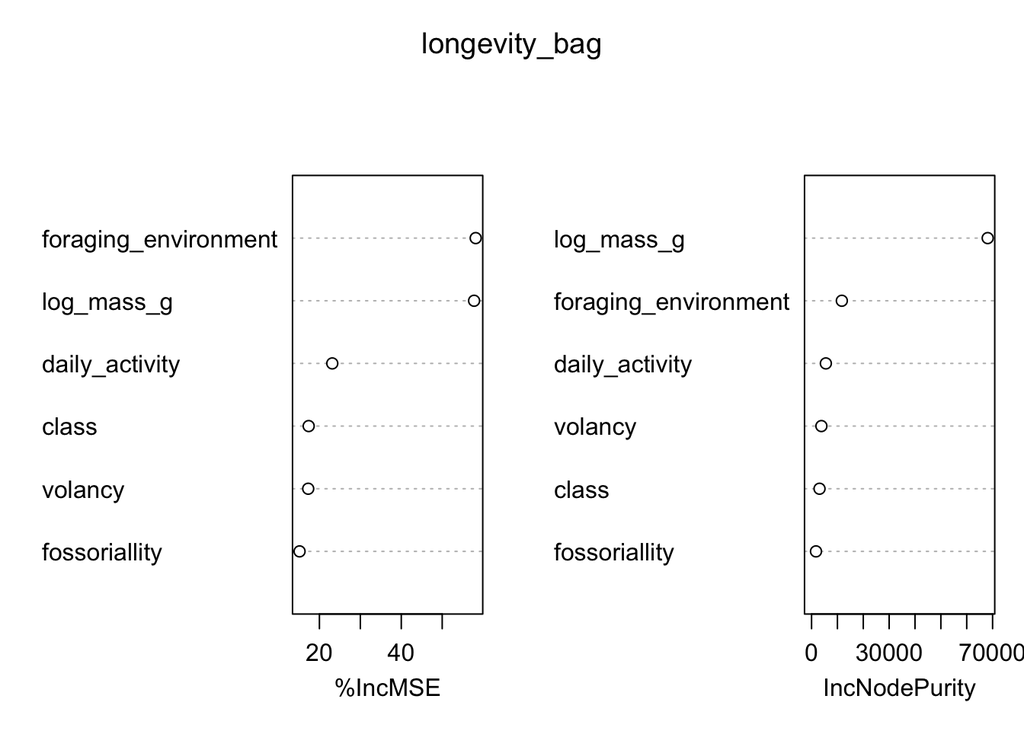

```r
varImpPlot(longevity_bag)
```

The most important variables are `log_mass_g`, `foraging_environment` and `daily_activity`.

## Random Forest

We use random forests with hyperparameter optimisation for $m$, the number of variables considered at each split.

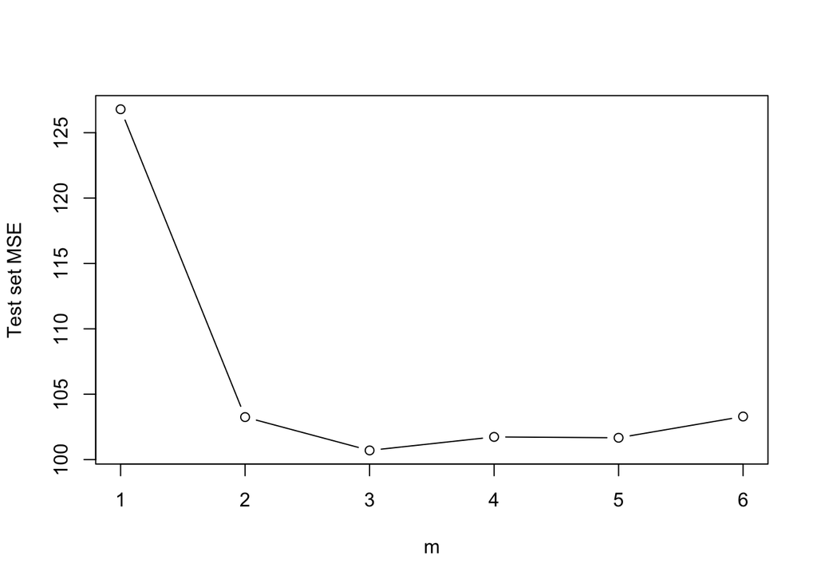

```r
rf_out <- sapply(1:6, function(i) {

  longevity_rf_i <- randomForest(
    maximum_lifespan_yr ~ .,
    data = train,
    mtry = i,
    importance = TRUE
  )

  rf_i_pred <- predict(longevity_rf_i, test)
  rf_i_mse <- mean((rf_i_pred - test$maximum_lifespan_yr)^2)

})

plot(1:6, rf_out, type = "b", xlab = "m", ylab = "Test set MSE")
```

Optimal value of $m = 3$.

```r
longevity_rf <- randomForest(
  maximum_lifespan_yr ~ .,
  data = train,
  mtry = 3,
  importance = TRUE
)

rf_pred_ts <- predict(longevity_rf, test)

rf_mse_tr <- mean((longevity_rf$predicted - train$maximum_lifespan_yr)^2)
rf_mse_ts <- mean((rf_pred_ts - test$maximum_lifespan_yr)^2)

method_eff[3, ] <- c("Random Forest", rf_mse_tr, rf_mse_ts)
```

## BART SIMPSON

```r
library(BART)

x_train <- train[, -2]
y_train <- train[, 2]

x_test <- test[, -2]
y_test <- test[, 2]

longevity_bart <- gbart(x_train, y_train, x.test = x_test)
```

```
## *****Calling gbart: type=1
## *****Data:
## data:n,p,np: 685, 17, 224
## y1,yn: -18.983066, -11.183066
## x1,x[n*p]: 0.000000, 1.826723
## xp1,xp[np*p]: 0.000000, 3.248709
## *****Number of Trees: 200
## *****Number of Cut Points: 1 ... 100
## *****burn,nd,thin: 100,1000,1
## *****Prior:beta,alpha,tau,nu,lambda,offset: 2,0.95,1.33997,3,16.7008,22.2831
## *****sigma: 9.259430
## *****w (weights): 1.000000 ... 1.000000
## *****Dirichlet:sparse,theta,omega,a,b,rho,augment: 0,0,1,0.5,1,17,0
## *****printevery: 100
##
## MCMC
## done 0 (out of 1100)
## done 100 (out of 1100)
## done 200 (out of 1100)
## done 300 (out of 1100)
## done 400 (out of 1100)
## done 500 (out of 1100)
## done 600 (out of 1100)
## done 700 (out of 1100)
## done 800 (out of 1100)
## done 900 (out of 1100)
## done 1000 (out of 1100)
## time: 4s
## trcnt,tecnt: 1000,1000
```

Calculate error:

```r
bart_pred_tr <- longevity_bart$yhat.train.mean
bart_pred_ts <- longevity_bart$yhat.test.mean

bart_mse_tr <- mean((bart_pred_tr - y_train)^2)
bart_mse_ts <- mean((bart_pred_ts - y_test)^2)

method_eff[4, ] <- c("BART", bart_mse_tr, bart_mse_ts)
```

Variable importances:

```r
ord <- order(longevity_bart$varcount.mean, decreasing = TRUE)
longevity_bart$varcount.mean[ord]
```

```
##            log_mass_g                class2 foraging_environment4              volancy1
##                24.408                15.639                14.950                14.691
##       daily_activity3       daily_activity4       daily_activity1 foraging_environment2
##                14.629                14.413                14.378                14.348
##                class1        fossoriallity2              volancy2 foraging_environment1
##                13.881                13.593                13.511                13.362
## foraging_environment5       daily_activity2        fossoriallity3 foraging_environment3
##                13.308                13.088                12.949                12.725
##        fossoriallity1
##                 0.000
```

## Linear models

Basic linear model:

```r
longevity_lm <- lm(maximum_lifespan_yr ~ ., data = train)

lm_pred_tr <- longevity_lm$fitted.values
lm_pred_ts <- predict(longevity_lm, test)

lm_mse_tr <- mean((lm_pred_tr - train$maximum_lifespan_yr)^2)
lm_mse_ts <- mean((lm_pred_ts - test$maximum_lifespan_yr)^2)

method_eff[5, ] <- c("Linear model", lm_mse_tr, lm_mse_ts)
```

## Conclusions

| method | mse_tr | mse_ts |
| --- | --- | --- |
| Boosting | 64.22226 | 94.11346 |
| BART | 67.82386 | 95.84475 |
| Random Forest | 74.98110 | 100.69313 |
| Regression Tree | 77.77872 | 109.09521 |
| Linear model | 84.10992 | 113.36489 |

Boosting is performing best out of all the methods explored on this data set.